# Lesson 9: Read and write files in R

Modesto

2022-11-11 (17:11 h)

# Wellcome & Disclaimer

This site contains the materials for the *Coding tools for Biochemistry & Molecular Biology* (Herramientas de Programación para Bioquímica y Biología Molecular) course of fall 2022 in the Bachelor’s Degree in Biochemistry @UAM. This materials are the basis for GitHub-pages-based website that can be accessed [here](https://mredrejo.github.io/HPBBM2022/). Detailed academic information about the course contents, dates and assessment only can be found at the UAM Moodle site.

All this material is open access and it is shared under [CC BY-NC](https://creativecommons.org/licenses/by-nc/2.0/) license.

# Data input & output in R

As you already know, launching R starts an interactive session with input from the keyboard and output to the screen. If you are using small datasets, you can directly define and introduce your data in the Console, as you did in the examples before. Additionally, you can define your objects and introduce your data interactively with the functions `scan()`and `readline()` as in the following examples. Regarding the output, you can just call the object by its name or use the function `print()`, which displays on the screen the contents of its argument object.

```r
vector <- scan(n = 4)
vector2 <- scan()
str <- readline()
vector
```

```
## [1]  3 45  6  5
```

```r
print(vector2)
```

```
## [1] 3
```

```r
print(str)
```

```
## [1] "hola"
```

```r
edit(str)
```

```
## [1] "Hola"
```

Although, seldom used, you can also edit the contents of your objects using the function `edit()`. This function can be used to edit different objects, including vectors, strings, matrices or dataframes. MacOS users need to install XQuartz X11 tool.

# Working directory

More often, you can process commands from a script file (a file containing R statements) and also import data from text files, databases (MySQL) or other proprietary formats, such as Excel or GraphPad Prism. We will focus on text files by the moment, as importing files in specific formats requires dedicated external packages. By default, R will read/write in the *working directory (wd)*, which is indicated in your Console panel.

[figure not shown]

Note that the abbreviation ‘~’ stands for your home directory (for me `/Users/modesto` or `/home/modesto` on MacOS or Linux, respectively).

The functions `getwd()` and `setwd()` allow you to check and change the *wd*. As this is a Markdown document, that `setwd()` within an R chunk only changes the working directory **for that particular chunk**. Remember that you can write `?getwd()` or `?setwd()` for help.

```r
getwd()
```

```
## [1] "/Users/modesto/data/HPBBM2022"
```

```r
setwd("/Users/modesto")
getwd()
```

```
## [1] "/Users/modesto"
```

```r
setwd("/Users/modsto/data/HPBBM2022")
```

```
## Error in setwd("/Users/modsto/data/HPBBM2022"): no es posible cambiar el directorio de trabajo
```

```r
setwd("/Users/modesto/data/HPBBM2022")
getwd()
```

```
## [1] "/Users/modesto/data/HPBBM2022"
```

In RStudio, the *default working directory* can be set from the “tools” and “global options” menu. Also, you can change the *wd* for your session in the menu **Session > Set Working Directory** and change it to that of source file (for instant your R script), the project or the selected directory in the files panel.

# Reading/writing data in R

The most common way to read your data in R is importing it as a table, using the function `read.table()`. Note that the resultant object will become a *Dataframe*, even when all the entries got to be numeric. A followup call towards `as.matrix()` will turn it into in a matrix.

In the following example we read a file called *small_matrix.csv*, located in the folder data. If we attempt to make some matrix calculations, R will force the dataframe to a matrix when possible, but it will return an Error for many matrix-specific operations or functions unless, we transform the dataframe into a matrix.

```r
sm <- read.table("data/small_matrix.csv", sep = ",")
sm
```

| V1 | V2 | V3 |
| --- | --- | --- |
| 2 | 7 | 19 |
| 22 | 10 | 80 |
| 18 | 3 | 13 |
| 25 | 6 | 16 |

```r
is.matrix(sm)
```

```
## [1] FALSE
```

```r
t(sm)
```

```
##    [,1] [,2] [,3] [,4]
## V1    2   22   18   25
## V2    7   10    3    6
## V3   19   80   13   16
```

```r
sm * 3
```

| V1 | V2 | V3 |
| --- | --- | --- |
| 6 | 21 | 57 |
| 66 | 30 | 240 |
| 54 | 9 | 39 |
| 75 | 18 | 48 |

```r
diag(sm)
```

```
## Error in diag(sm): 'list' object cannot be coerced to type 'double'
```

```r
diag(as.matrix(sm))
```

```
## [1]  2 10 13
```

```r
heatmap(sm)
```

```
## Error in heatmap(sm): 'x' must be a numeric matrix
```

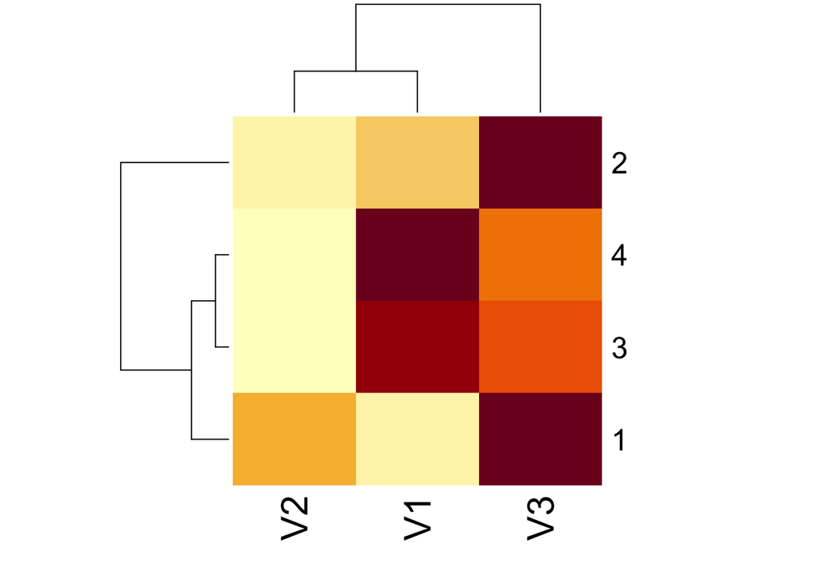

```r
heatmap(as.matrix(sm))
```

You can write any data object(s) as binary data file or as text files.

```r
write(vector2, file = "data/vector2.txt")
write.table(sm, "data/sm.csv")
write.table(sm, "data/sm2.csv", row.names = FALSE, col.names = FALSE,
    sep = ";")

save(vector, vector2, file = "data/vector2.Rdata")
save.image(file = "data/myEnvironment.RData")
```

Data files in RData format can be open from the *Environment* tab or with the `load()` function

```r
sm_bis <- load("data/vector2.Rdata")
sm_bis
```

```
## [1] "vector"  "vector2"
```

# Basic Data Management in R

Now we are going to import and explore an example dataset, containing metadata from an Illumina sequencing project of pathogenic *E. coli* strains (Flament-Simon et al. 2020, https://doi.org/10.1038/s41598-020-69356-6). However, for didactic purposes, the original data have been simplified and manipulated and the attached datasets do not fully correspond to the actual data.

## Explore a dataframe

As you can see in the R help, the function `read.table()` has several default options as FALSE, like `header=FALSE`. When you have a spreadsheet export file, i.e. having a table where the fields are divided by commas in place of spaces, you can use `read.csv()` in place of read.table(). For Spaniards, there is also `read.csv2()`, which uses a comma for the decimal point and a semicolon for the separator. The latter functions are wrappers of `read.table()` with custom default options.

```r
# Note differences between read.table(), read.csv() and
# read.csv2()
coli_genomes <- read.table(file = "data/coli_genomes.csv")
```

```
## Error in scan(file = file, what = what, sep = sep, quote = quote, dec = dec, : line 2 did not have 11 elements
```

```r
head(coli_genomes)
```

[output not shown]

```r
coli_genomes <- read.table(file = "data/coli_genomes.csv", sep = ";",
    dec = ".", header = TRUE)
head(coli_genomes)
```

|  | Strain | Biosample | Year.of.isolation | Source | Phylogroup | Serotype | Clonotype | Sequence.Type | VF | No..Plasmids | kmer | Contigs | N50 | longest.contig..bp. | total.assembled.bp | contigs...1kb |
| --- | --- | --- | --- | --- | --- | --- | --- | --- | --- | --- | --- | --- | --- | --- | --- | --- |
| 1 | LREC237 | SAMN14278613 | NA | Human | D | ONT:H28 | CH23-331 | ST524 | 18 | 3 | 117 | 223 | 272287 | 662555 | 5341632 | 74 |
| 2 | LREC239 | SAMN14278614 | 2010 | Human | C | O153:H19 | CH4-25 | ST88 | 14 | 3 | 117 | 159 | 323172 | 760527 | 5415613 | 57 |
| 3 | LREC240 | SAMN14278615 | 2008 | Human | B1 | O76:H30 | CH29-38 | ST156 | 10 | 2 | 89 | 114 | 270767 | 738861 | 4875343 | 47 |
| 4 | LREC241 | SAMN14278616 | NA | Human | A | O78:H11 | CH11-41 | ST48 | 5 | 3 | 117 | 212 | 112160 | 285056 | 5167401 | 101 |
| 5 | LREC242 | SAMN14278617 | 2011 | Porcine | A | ONT:HNM | CH7-54 | ST746 | 5 | 9 | 89 | 320 | 45936 | 128053 | 4858138 | 212 |
| 6 | LREC243 | SAMN14278618 | 2007 | Porcine | A | O9:H37 | CH7-31 | ST3011 | 7 | 3 | 93 | 158 | 106897 | 369508 | 4638334 | 93 |

```r
coli_genomes <- read.csv(file = "data/coli_genomes.csv")
head(coli_genomes)
```

|  | Strain.Biosample.Year.of.isolation.Source.Phylogroup.Serotype.Clonotype.Sequence.Type.VF.No..Plasmids.kmer.Contigs.N50.longest.contig..bp..total.assembled.bp.contigs...1kb |
| --- | --- |
| 1 | LREC237;SAMN14278613;NA;Human ;D;ONT:H28;CH23-331;ST524;18;3;117;223;272287;662555;5341632;74 |
| 2 | LREC239;SAMN14278614;2010;Human ;C;O153:H19;CH4-25;ST88;14;3;117;159;323172;760527;5415613;57 |
| 3 | LREC240;SAMN14278615;2008;Human ;B1;O76:H30;CH29-38;ST156;10;2;89;114;270767;738861;4875343;47 |
| 4 | LREC241;SAMN14278616;NA;Human;A;O78:H11;CH11-41;ST48;5;3;117;212;112160;285056;5167401;101 |
| 5 | LREC242;SAMN14278617;2011;Porcine ;A;ONT:HNM;CH7-54;ST746;5;9;89;320;45936;128053;4858138;212 |
| 6 | LREC243;SAMN14278618;2007;Porcine ;A;O9:H37;CH7-31;ST3011;7;3;93;158;106897;369508;4638334;93 |

```r
coli_genomes <- read.csv(file = "data/coli_genomes.csv", sep = ";")
head(coli_genomes)
```

|  | Strain | Biosample | Year.of.isolation | Source | Phylogroup | Serotype | Clonotype | Sequence.Type | VF | No..Plasmids | kmer | Contigs | N50 | longest.contig..bp. | total.assembled.bp | contigs...1kb |
| --- | --- | --- | --- | --- | --- | --- | --- | --- | --- | --- | --- | --- | --- | --- | --- | --- |
| 1 | LREC237 | SAMN14278613 | NA | Human | D | ONT:H28 | CH23-331 | ST524 | 18 | 3 | 117 | 223 | 272287 | 662555 | 5341632 | 74 |
| 2 | LREC239 | SAMN14278614 | 2010 | Human | C | O153:H19 | CH4-25 | ST88 | 14 | 3 | 117 | 159 | 323172 | 760527 | 5415613 | 57 |
| 3 | LREC240 | SAMN14278615 | 2008 | Human | B1 | O76:H30 | CH29-38 | ST156 | 10 | 2 | 89 | 114 | 270767 | 738861 | 4875343 | 47 |
| 4 | LREC241 | SAMN14278616 | NA | Human | A | O78:H11 | CH11-41 | ST48 | 5 | 3 | 117 | 212 | 112160 | 285056 | 5167401 | 101 |
| 5 | LREC242 | SAMN14278617 | 2011 | Porcine | A | ONT:HNM | CH7-54 | ST746 | 5 | 9 | 89 | 320 | 45936 | 128053 | 4858138 | 212 |
| 6 | LREC243 | SAMN14278618 | 2007 | Porcine | A | O9:H37 | CH7-31 | ST3011 | 7 | 3 | 93 | 158 | 106897 | 369508 | 4638334 | 93 |

```r
coli_genomes <- read.csv2(file = "data/coli_genomes.csv")
head(coli_genomes)
```

|  | Strain | Biosample | Year.of.isolation | Source | Phylogroup | Serotype | Clonotype | Sequence.Type | VF | No..Plasmids | kmer | Contigs | N50 | longest.contig..bp. | total.assembled.bp | contigs...1kb |
| --- | --- | --- | --- | --- | --- | --- | --- | --- | --- | --- | --- | --- | --- | --- | --- | --- |
| 1 | LREC237 | SAMN14278613 | NA | Human | D | ONT:H28 | CH23-331 | ST524 | 18 | 3 | 117 | 223 | 272287 | 662555 | 5341632 | 74 |
| 2 | LREC239 | SAMN14278614 | 2010 | Human | C | O153:H19 | CH4-25 | ST88 | 14 | 3 | 117 | 159 | 323172 | 760527 | 5415613 | 57 |
| 3 | LREC240 | SAMN14278615 | 2008 | Human | B1 | O76:H30 | CH29-38 | ST156 | 10 | 2 | 89 | 114 | 270767 | 738861 | 4875343 | 47 |
| 4 | LREC241 | SAMN14278616 | NA | Human | A | O78:H11 | CH11-41 | ST48 | 5 | 3 | 117 | 212 | 112160 | 285056 | 5167401 | 101 |
| 5 | LREC242 | SAMN14278617 | 2011 | Porcine | A | ONT:HNM | CH7-54 | ST746 | 5 | 9 | 89 | 320 | 45936 | 128053 | 4858138 | 212 |
| 6 | LREC243 | SAMN14278618 | 2007 | Porcine | A | O9:H37 | CH7-31 | ST3011 | 7 | 3 | 93 | 158 | 106897 | 369508 | 4638334 | 93 |

```r
# read some data
head(coli_genomes)
```

|  | Strain | Biosample | Year.of.isolation | Source | Phylogroup | Serotype | Clonotype | Sequence.Type | VF | No..Plasmids | kmer | Contigs | N50 | longest.contig..bp. | total.assembled.bp | contigs...1kb |
| --- | --- | --- | --- | --- | --- | --- | --- | --- | --- | --- | --- | --- | --- | --- | --- | --- |
| 1 | LREC237 | SAMN14278613 | NA | Human | D | ONT:H28 | CH23-331 | ST524 | 18 | 3 | 117 | 223 | 272287 | 662555 | 5341632 | 74 |
| 2 | LREC239 | SAMN14278614 | 2010 | Human | C | O153:H19 | CH4-25 | ST88 | 14 | 3 | 117 | 159 | 323172 | 760527 | 5415613 | 57 |
| 3 | LREC240 | SAMN14278615 | 2008 | Human | B1 | O76:H30 | CH29-38 | ST156 | 10 | 2 | 89 | 114 | 270767 | 738861 | 4875343 | 47 |
| 4 | LREC241 | SAMN14278616 | NA | Human | A | O78:H11 | CH11-41 | ST48 | 5 | 3 | 117 | 212 | 112160 | 285056 | 5167401 | 101 |
| 5 | LREC242 | SAMN14278617 | 2011 | Porcine | A | ONT:HNM | CH7-54 | ST746 | 5 | 9 | 89 | 320 | 45936 | 128053 | 4858138 | 212 |
| 6 | LREC243 | SAMN14278618 | 2007 | Porcine | A | O9:H37 | CH7-31 | ST3011 | 7 | 3 | 93 | 158 | 106897 | 369508 | 4638334 | 93 |

```r
tail(coli_genomes, n = 2)
```

|  | Strain | Biosample | Year.of.isolation | Source | Phylogroup | Serotype | Clonotype | Sequence.Type | VF | No..Plasmids | kmer | Contigs | N50 | longest.contig..bp. | total.assembled.bp | contigs...1kb |
| --- | --- | --- | --- | --- | --- | --- | --- | --- | --- | --- | --- | --- | --- | --- | --- | --- |
| 24 | LREC261 | SAMN14278636 | 2016 | Human | A | O98:H26 | CH27-23 | ST8233 | 2 | 4 | 89 | 114 | 187945 | 537848 | 4821342 | 53 |
| 25 | LREC262 | SAMN14278637 | 2012 | Human | B1 | O66:H10 | CH4-32 | ST1049 | 4 | 2 | 113 | 94 | 325747 | 822206 | 4839344 | 32 |

```r
coli_genomes[1, ]
```

|  | Strain | Biosample | Year.of.isolation | Source | Phylogroup | Serotype | Clonotype | Sequence.Type | VF | No..Plasmids | kmer | Contigs | N50 | longest.contig..bp. | total.assembled.bp | contigs...1kb |
| --- | --- | --- | --- | --- | --- | --- | --- | --- | --- | --- | --- | --- | --- | --- | --- | --- |
| 1 | LREC237 | SAMN14278613 | NA | Human | D | ONT:H28 | CH23-331 | ST524 | 18 | 3 | 117 | 223 | 272287 | 662555 | 5341632 | 74 |

```r
coli_genomes[, 1]
```

```
##  [1] "LREC237" "LREC239" "LREC240" "LREC241" "LREC242" "LREC243" "LREC244" "LREC245" "LREC246"
## [10] "LREC247" "LREC248" "LREC249" "LREC250" "LREC251" "LREC252" "LREC253" "LREC254" "LREC255"
## [19] "LREC256" "LREC257" "LREC258" "LREC259" "LREC260" "LREC261" "LREC262"
```

```r
coli_genomes[1:6, 2:4]
```

|  | Biosample | Year.of.isolation | Source |
| --- | --- | --- | --- |
| 1 | SAMN14278613 | NA | Human |
| 2 | SAMN14278614 | 2010 | Human |
| 3 | SAMN14278615 | 2008 | Human |
| 4 | SAMN14278616 | NA | Human |
| 5 | SAMN14278617 | 2011 | Porcine |
| 6 | SAMN14278618 | 2007 | Porcine |

```r
# explore the dataframe structure
dim(coli_genomes)
```

```
## [1] 25 16
```

```r
length(coli_genomes)
```

```
## [1] 16
```

```r
ncol(coli_genomes)
```

```
## [1] 16
```

```r
nrow(coli_genomes)
```

```
## [1] 25
```

```r
# dataframe estructure in one line
str(coli_genomes)
```

```
## 'data.frame':    25 obs. of  16 variables:
##  $ Strain             : chr  "LREC237" "LREC239" "LREC240" "LREC241" ...
##  $ Biosample          : chr  "SAMN14278613" "SAMN14278614" "SAMN14278615" "SAMN14278616" ...
##  $ Year.of.isolation  : int  NA 2010 2008 NA 2011 2007 2006 2006 2010 2013 ...
##  $ Source             : chr  "Human " "Human " "Human " "Human" ...
##  $ Phylogroup         : chr  "D" "C" "B1" "A" ...
##  $ Serotype           : chr  "ONT:H28" "O153:H19" "O76:H30" "O78:H11" ...
##  $ Clonotype          : chr  "CH23-331" "CH4-25" "CH29-38" "CH11-41" ...
##  $ Sequence.Type      : chr  "ST524" "ST88" "ST156" "ST48" ...
##  $ VF                 : int  18 14 10 5 5 7 4 2 10 22 ...
##  $ No..Plasmids       : int  3 3 2 3 9 3 7 7 1 4 ...
##  $ kmer               : int  117 117 89 117 89 93 115 115 113 113 ...
##  $ Contigs            : int  223 159 114 212 320 158 277 203 131 215 ...
##  $ N50                : int  272287 323172 270767 112160 45936 106897 89185 94368 326769 248158 ...
##  $ longest.contig..bp.: int  662555 760527 738861 285056 128053 369508 281444 280268 451887 504233 ...
##  $ total.assembled.bp : int  5341632 5415613 4875343 5167401 4858138 4638334 5406295 4796593 5173794 5364777 ...
##  $ contigs...1kb      : int  74 57 47 101 212 93 155 114 56 76 ...
```

```r
# type of data in each variable
typeof(coli_genomes$Strain)
```

```
## [1] "character"
```

```r
typeof(coli_genomes[, 2])
```

```
## [1] "character"
```

```r
typeof(coli_genomes[, 9])
```

```
## [1] "integer"
```

```r
# col and row names
names(coli_genomes)
```

```
##  [1] "Strain"              "Biosample"           "Year.of.isolation"   "Source"
##  [5] "Phylogroup"          "Serotype"            "Clonotype"           "Sequence.Type"
##  [9] "VF"                  "No..Plasmids"        "kmer"                "Contigs"
## [13] "N50"                 "longest.contig..bp." "total.assembled.bp"  "contigs...1kb"
```

```r
colnames(coli_genomes)
```

```
##  [1] "Strain"              "Biosample"           "Year.of.isolation"   "Source"
##  [5] "Phylogroup"          "Serotype"            "Clonotype"           "Sequence.Type"
##  [9] "VF"                  "No..Plasmids"        "kmer"                "Contigs"
## [13] "N50"                 "longest.contig..bp." "total.assembled.bp"  "contigs...1kb"
```

```r
rownames(coli_genomes)
```

```
##  [1] "1"  "2"  "3"  "4"  "5"  "6"  "7"  "8"  "9"  "10" "11" "12" "13" "14" "15" "16" "17" "18" "19"
## [20] "20" "21" "22" "23" "24" "25"
```

```r
names(coli_genomes[3]) <- "Year"
names(coli_genomes)[3] <- "Year"
colnames(coli_genomes[3]) <- "Year"
```

Some of the columns include ‘chr’ data that may be actually a categorical variable, so we can code them as **factor**. Using the expression *as.factor()* you can check whether the data would correspond to a text or a categorical variable.

```r
coli_genomes$Source <- as.factor(coli_genomes$Source)
coli_genomes$Phylogroup <- as.factor(coli_genomes$Phylogroup)

str(coli_genomes)  #dataframe estructure updated
```

```
## 'data.frame':    25 obs. of  16 variables:
##  $ Strain             : chr  "LREC237" "LREC239" "LREC240" "LREC241" ...
##  $ Biosample          : chr  "SAMN14278613" "SAMN14278614" "SAMN14278615" "SAMN14278616" ...
##  $ Year               : int  NA 2010 2008 NA 2011 2007 2006 2006 2010 2013 ...
##  $ Source             : Factor w/ 4 levels "Avian ","Human",..: 3 3 3 2 4 4 4 4 4 3 ...
##  $ Phylogroup         : Factor w/ 4 levels "A","B1","C","D": 4 3 2 1 1 1 1 1 3 4 ...
##  $ Serotype           : chr  "ONT:H28" "O153:H19" "O76:H30" "O78:H11" ...
##  $ Clonotype          : chr  "CH23-331" "CH4-25" "CH29-38" "CH11-41" ...
##  $ Sequence.Type      : chr  "ST524" "ST88" "ST156" "ST48" ...
##  $ VF                 : int  18 14 10 5 5 7 4 2 10 22 ...
##  $ No..Plasmids       : int  3 3 2 3 9 3 7 7 1 4 ...
##  $ kmer               : int  117 117 89 117 89 93 115 115 113 113 ...
##  $ Contigs            : int  223 159 114 212 320 158 277 203 131 215 ...
##  $ N50                : int  272287 323172 270767 112160 45936 106897 89185 94368 326769 248158 ...
##  $ longest.contig..bp.: int  662555 760527 738861 285056 128053 369508 281444 280268 451887 504233 ...
##  $ total.assembled.bp : int  5341632 5415613 4875343 5167401 4858138 4638334 5406295 4796593 5173794 5364777 ...
##  $ contigs...1kb      : int  74 57 47 101 212 93 155 114 56 76 ...
```

How many levels are there in *Source*?? It is not uncommon to see some mistake in our data, usually made when the data were recorded, for example a space may have been inserted before a data value. By default this white space will be kept in the R environment, such that ‘Human’ will be recognized as a different value than ‘Human’. In order to avoid this type of error, we can use the *strip.white* argument.

```r
unique(coli_genomes$Source)
```

```
## [1] Human    Human    Porcine  Avian
## Levels: Avian  Human Human  Porcine
```

```r
table(coli_genomes$Source)
```

```
##
##   Avian     Human   Human  Porcine
##        3        1       16        5
```

```r
coli_genomes <- read.csv2(file = "data/coli_genomes.csv", strip.white = TRUE)
coli_genomes$Source <- as.factor(coli_genomes$Source)
coli_genomes$Phylogroup <- as.factor(coli_genomes$Phylogroup)

unique(coli_genomes$Source)
```

```
## [1] Human   Porcine Avian
## Levels: Avian Human Porcine
```

We can also rename some variables to use more easy names.

```r
names(coli_genomes)  #see all variable names
```

```
##  [1] "Strain"              "Biosample"           "Year.of.isolation"   "Source"
##  [5] "Phylogroup"          "Serotype"            "Clonotype"           "Sequence.Type"
##  [9] "VF"                  "No..Plasmids"        "kmer"                "Contigs"
## [13] "N50"                 "longest.contig..bp." "total.assembled.bp"  "contigs...1kb"
```

```r
# rename variables
names(coli_genomes)[3] <- "Year"
names(coli_genomes)[10] <- "Plasmids"
names(coli_genomes)[15] <- "Assembly_length"
names(coli_genomes)[16] <- "contigs1kb"
# check
names(coli_genomes)
```

```
##  [1] "Strain"              "Biosample"           "Year"                "Source"
##  [5] "Phylogroup"          "Serotype"            "Clonotype"           "Sequence.Type"
##  [9] "VF"                  "Plasmids"            "kmer"                "Contigs"
## [13] "N50"                 "longest.contig..bp." "Assembly_length"     "contigs1kb"
```